# Practical Case: Credit Approval

### Definition

We are going to take the credit approval dataset on https://archive.ics.uci.edu/ml/datasets/Credit+Approval. The dataset information is on https://archive.ics.uci.edu/ml/machine-learning-databases/credit-screening/crx.names and it is the following:

```
  1. Title: Credit Approval

  2. Sources:
      (confidential)
      Submitted by quinlan@cs.su.oz.au

  3.  Past Usage:

      See Quinlan,
      * "Simplifying decision trees", Int J Man-Machine Studies 27,
        Dec 1987, pp. 221-234.
      * "C4.5: Programs for Machine Learning", Morgan Kaufmann, Oct 1992

  4.  Relevant Information:

      This file concerns credit card applications.  All attribute names
      and values have been changed to meaningless symbols to protect
      confidentiality of the data.

      This dataset is interesting because there is a good mix of
      attributes -- continuous, nominal with small numbers of
      values, and nominal with larger numbers of values.  There
      are also a few missing values.

  5.  Number of Instances: 690

  6.  Number of Attributes: 15 + class attribute

  7.  Attribute Information:

      A1:   b, a.
      A2:   continuous.
      A3:   continuous.
      A4:   u, y, l, t.
      A5:   g, p, gg.
      A6:   c, d, cc, i, j, k, m, r, q, w, x, e, aa, ff.
      A7:   v, h, bb, j, n, z, dd, ff, o.
      A8:   continuous.
      A9:   t, f.
      A10:  t, f.
```

[output cut: 8 more lines]

```
      37 cases (5%) have one or more missing values.  The missing
      values from particular attributes are:

      A1:  12
      A2:  12
      A4:   6
      A5:   6
      A6:   9
      A7:   9
      A14: 13

  9.  Class Distribution

      +: 307 (44.5%)
      -: 383 (55.5%)
```

#### To do

1. Load data. Make a inspection by variables of the credit approval distribution according to each attribute visually. Make the relevant observations. What variables are better for separating data?
2. Prepare dataset conveniently and impute the missing values using the `missForest` library.
3. Divide dataset taking the first 590 instances like train and the last 100 like test.
4. Train a logistical regression model with Ridge and Lasso regularization on train, selecting the model which has higher `AUC`. Give the metrics in test.
5. Give the *log odds* of the predictors variables above the objective variable.
6. If for each true positive we earn 100e and for each false positive we lost 20e, what rentability contributes apply this model?

### 1. Load data. Make a inspection by variables of the credit approval distribution according to each attribute visually. Make the relevant observations. What variables are better for separating data?

```r
# Read data using this URL:
url <- "https://archive.ics.uci.edu/ml/machine-learning-databases/credit-screening/crx.data"
data <- read.csv(url, header = FALSE)
# If this URL is not enabled, load data:
# data <- read.csv("data/credit-approval.csv")
head(data)
```

|  | V1 | V2 | V3 | V4 | V5 | V6 | V7 | V8 | V9 | V10 | V11 | V12 | V13 | V14 | V15 | V16 |
| --- | --- | --- | --- | --- | --- | --- | --- | --- | --- | --- | --- | --- | --- | --- | --- | --- |
| 1 | b | 30.83 | 0.000 | u | g | w | v | 1.25 | t | t | 1 | f | g | 00202 | 0 | + |
| 2 | a | 58.67 | 4.460 | u | g | q | h | 3.04 | t | t | 6 | f | g | 00043 | 560 | + |
| 3 | a | 24.50 | 0.500 | u | g | q | h | 1.50 | t | f | 0 | f | g | 00280 | 824 | + |
| 4 | b | 27.83 | 1.540 | u | g | w | v | 3.75 | t | t | 5 | t | g | 00100 | 3 | + |
| 5 | b | 20.17 | 5.625 | u | g | w | v | 1.71 | t | f | 0 | f | s | 00120 | 0 | + |
| 6 | b | 32.08 | 4.000 | u | g | m | v | 2.50 | t | f | 0 | t | g | 00360 | 0 | + |

```r
str(data)
```

```
'data.frame':   690 obs. of  16 variables:
 $ V1 : Factor w/ 3 levels "?","a","b": 3 2 2 3 3 3 3 2 3 3 ...
 $ V2 : Factor w/ 350 levels "?","13.75","15.17",..: 158 330 91 127 45 170 181 76 312 257 ...
 $ V3 : num  0 4.46 0.5 1.54 5.62 ...
 $ V4 : Factor w/ 4 levels "?","l","u","y": 3 3 3 3 3 3 3 3 4 4 ...
 $ V5 : Factor w/ 4 levels "?","g","gg","p": 2 2 2 2 2 2 2 2 4 4 ...
 $ V6 : Factor w/ 15 levels "?","aa","c","cc",..: 14 12 12 14 14 11 13 4 10 14 ...
 $ V7 : Factor w/ 10 levels "?","bb","dd",..: 9 5 5 9 9 9 5 9 5 9 ...
 $ V8 : num  1.25 3.04 1.5 3.75 1.71 ...
 $ V9 : Factor w/ 2 levels "f","t": 2 2 2 2 2 2 2 2 2 2 ...
 $ V10: Factor w/ 2 levels "f","t": 2 2 1 2 1 1 1 1 1 1 ...
 $ V11: int  1 6 0 5 0 0 0 0 0 0 ...
 $ V12: Factor w/ 2 levels "f","t": 1 1 1 2 1 2 2 1 1 2 ...
 $ V13: Factor w/ 3 levels "g","p","s": 1 1 1 1 3 1 1 1 1 1 ...
 $ V14: Factor w/ 171 levels "?","00000","00017",..: 70 13 98 33 39 117 56 25 64 17 ...
 $ V15: int  0 560 824 3 0 0 31285 1349 314 1442 ...
 $ V16: Factor w/ 2 levels "-","+": 2 2 2 2 2 2 2 2 2 2 ...
```

```r
summary(data)
```

```
 V1            V2            V3         V4       V5            V6            V7            V8         V9      V10          V11       V12
 ?: 12   ?      : 12   Min.   : 0.000   ?:  6   ? :  6   c      :137   v      :399   Min.   : 0.000   f:329   f:395   Min.   : 0.0   f:374
 a:210   22.67  :  9   1st Qu.: 1.000   l:  2   g :519   q      : 78   h      :138   1st Qu.: 0.165   t:361   t:295   1st Qu.: 0.0   t:316
 b:468   20.42  :  7   Median : 2.750   u:519   gg:  2   w      : 64   bb     : 59   Median : 1.000                   Median : 0.0
         18.83  :  6   Mean   : 4.759   y:163   p :163   i      : 59   ff     : 57   Mean   : 2.223                   Mean   : 2.4
         19.17  :  6   3rd Qu.: 7.207                    aa     : 54   ?      :  9   3rd Qu.: 2.625                   3rd Qu.: 3.0
         20.67  :  6   Max.   :28.000                    ff     : 53   j      :  8   Max.   :28.500                   Max.   :67.0
         (Other):644                                     (Other):245   (Other): 20
 V13          V14           V15           V16
 g:625   00000  :132   Min.   :     0.0   -:383
 p:  8   00120  : 35   1st Qu.:     0.0   +:307
 s: 57   00200  : 35   Median :     5.0
         00160  : 34   Mean   :  1017.4
         00080  : 30   3rd Qu.:   395.5
         00100  : 30   Max.   :100000.0
         (Other):394
```

We are going to make the visual inspection for each variable:

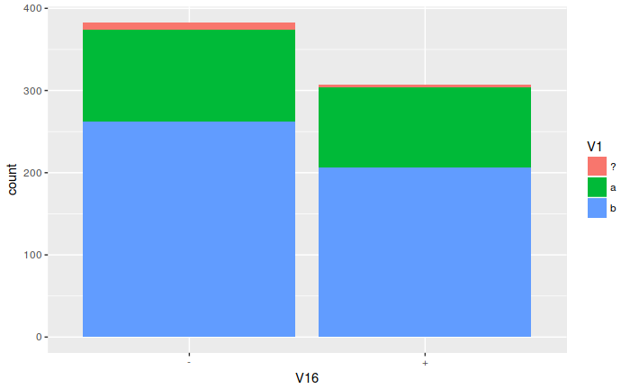

```r
library(ggplot2)
# V1
ggplot(data, aes(x = V16, fill = V1)) +
  geom_bar()
```

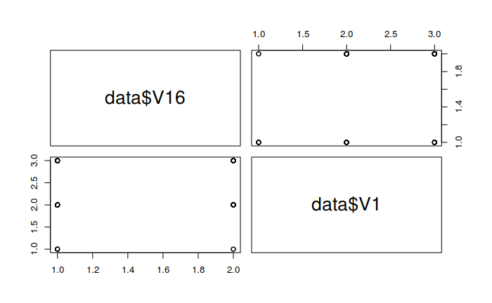

```r
pairs(data$V16 ~ data$V1)
```

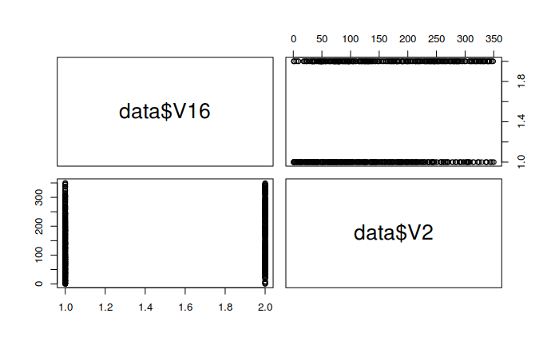

```r
# V2
pairs(data$V16 ~ data$V2)
```

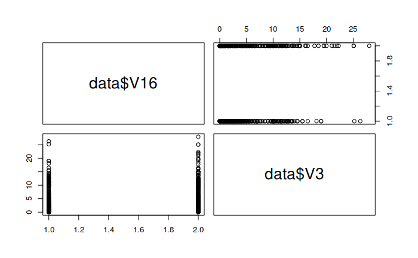

```r
# V3
pairs(data$V16 ~ data$V3)
```

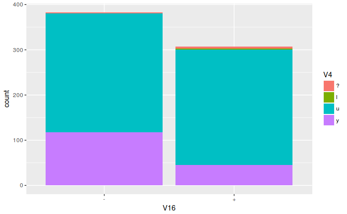

```r
# V4
ggplot(data, aes(x = V16, fill = V4)) +
  geom_bar()
```

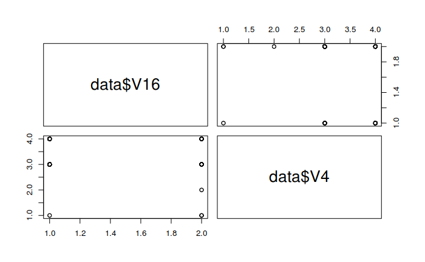

```r
pairs(data$V16 ~ data$V4)
```

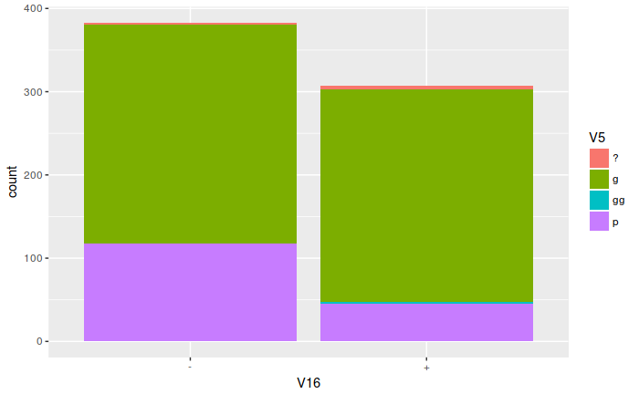

```r
# V5
ggplot(data, aes(x = V16, fill = V5)) +
  geom_bar()
```

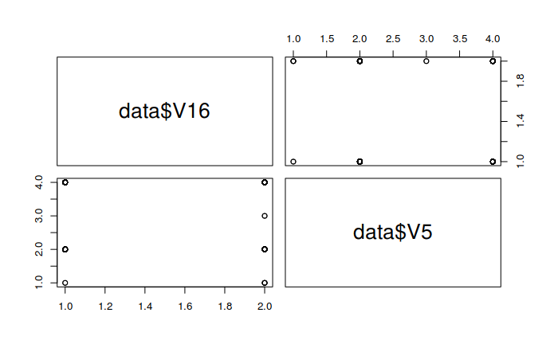

```r
pairs(data$V16 ~ data$V5)
```

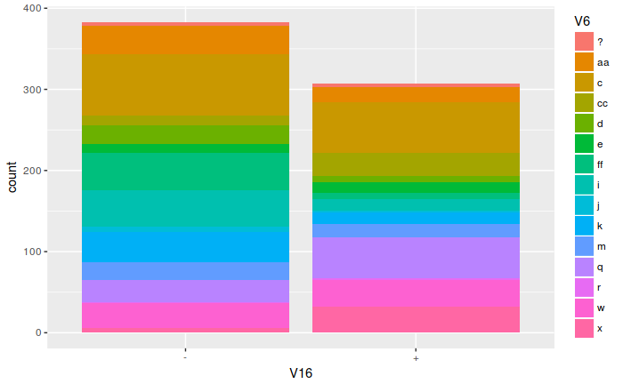

```r
# V6
ggplot(data, aes(x = V16, fill = V6)) +
  geom_bar()
```

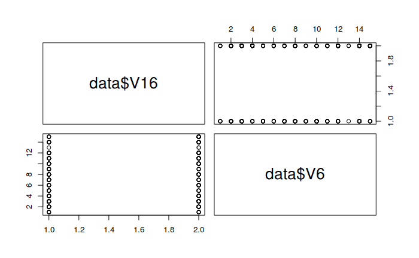

```r
pairs(data$V16 ~ data$V6)
```

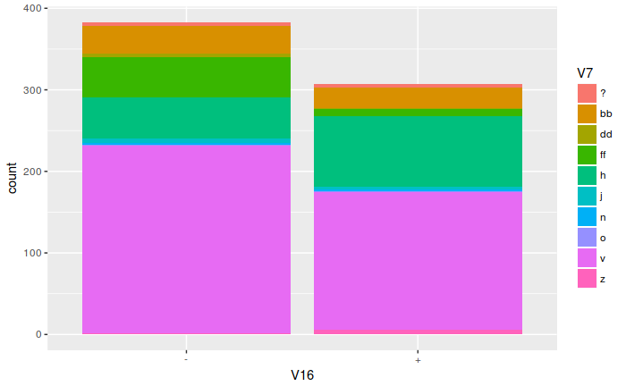

```r
# V7
ggplot(data, aes(x = V16, fill = V7)) +
  geom_bar()
```

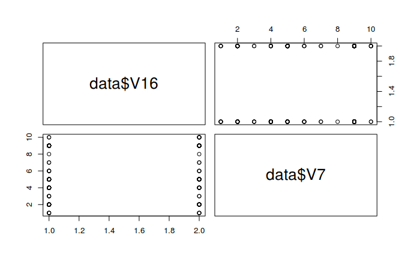

```r
pairs(data$V16 ~ data$V7)
```

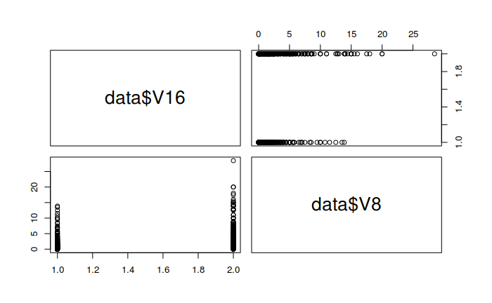

```r
# V8
pairs(data$V16 ~ data$V8)
```

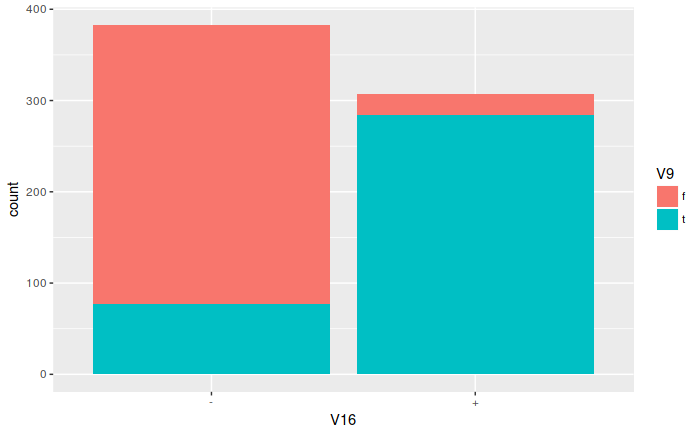

```r
# V9
ggplot(data, aes(x = V16, fill = V9)) +
  geom_bar()
```

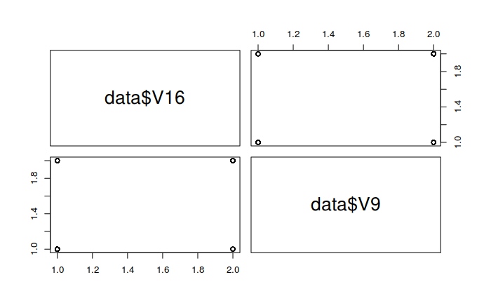

```r
pairs(data$V16 ~ data$V9)
```

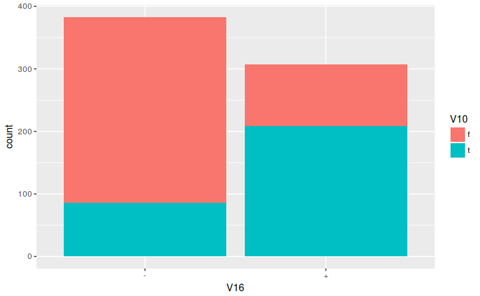

```r
# V10
ggplot(data, aes(x = V16, fill = V10)) +
  geom_bar()
```

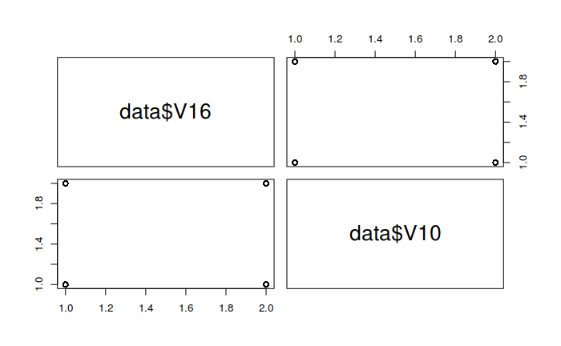

```r
pairs(data$V16 ~ data$V10)
```

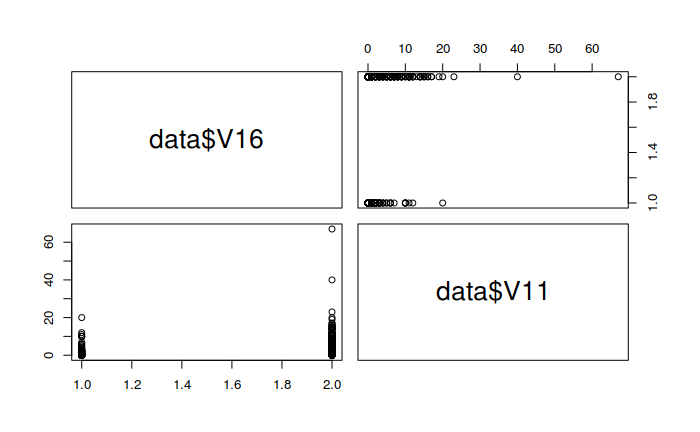

```r
# V11
pairs(data$V16 ~ data$V11)
```

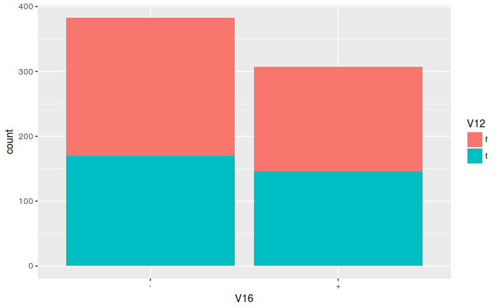

```r
# V12
ggplot(data, aes(x = V16, fill = V12)) +
  geom_bar()
```

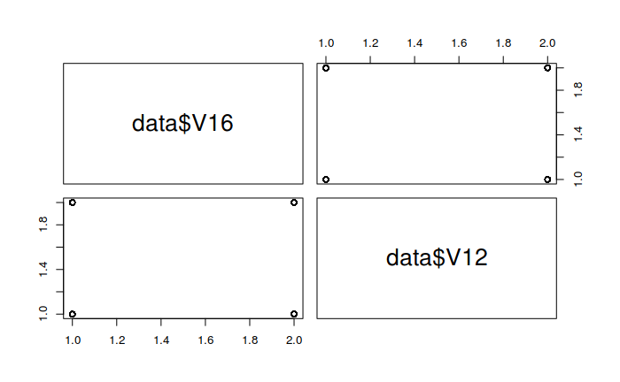

```r
pairs(data$V16 ~ data$V12)
```

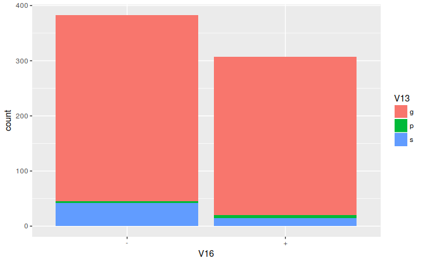

```r
# V13
ggplot(data, aes(x = V16, fill = V13)) +
  geom_bar()
```

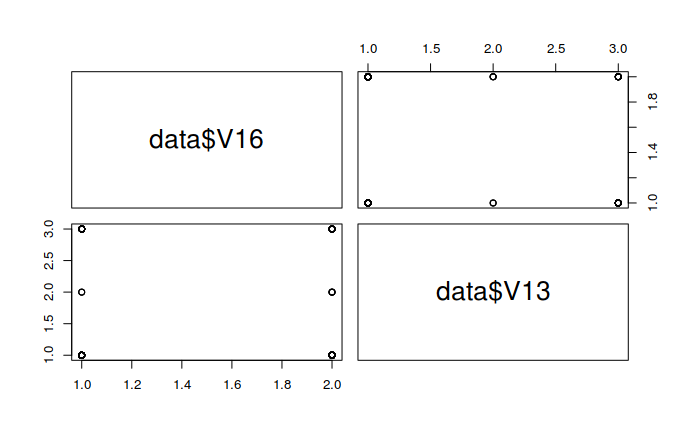

```r
pairs(data$V16 ~ data$V13)
```

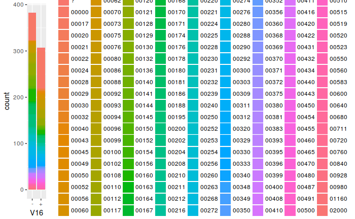

```r
# V14
ggplot(data, aes(x = V16, fill = V14)) +
  geom_bar()
```

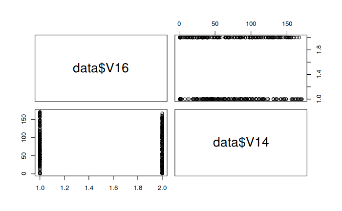

```r
pairs(data$V16 ~ data$V14)
```

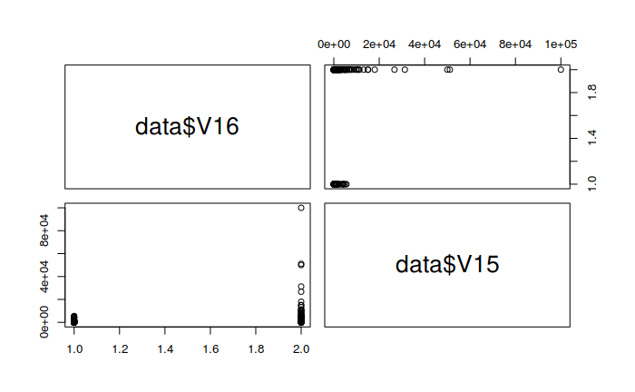

```r
# V15
pairs(data$V16 ~ data$V15)
```

We can observe the following:

### 2. Prepare dataset conveniently and impute the missing values using the `missForest` library.

In this dataset, the missing values are like `?` value. For that, we are going to convert this value to `NA` value.

```r
data[data == '?'] <- NA
summary(data)
```

```
    V1            V2            V3            V4         V5            V6            V7            V8         V9      V10          V11
 ?   :  0   22.67  :  9   Min.   : 0.000   ?   :  0   ?   :  0   c      :137   v      :399   Min.   : 0.000   f:329   f:395   Min.   : 0.0
 a   :210   20.42  :  7   1st Qu.: 1.000   l   :  2   g   :519   q      : 78   h      :138   1st Qu.: 0.165   t:361   t:295   1st Qu.: 0.0
 b   :468   18.83  :  6   Median : 2.750   u   :519   gg  :  2   w      : 64   bb     : 59   Median : 1.000                   Median : 0.0
 NA's: 12   19.17  :  6   Mean   : 4.759   y   :163   p   :163   i      : 59   ff     : 57   Mean   : 2.223                   Mean   : 2.4
            20.67  :  6   3rd Qu.: 7.207   NA's:  6   NA's:  6   aa     : 54   j      :  8   3rd Qu.: 2.625                   3rd Qu.: 3.0
            (Other):644   Max.   :28.000                         (Other):289   (Other): 20   Max.   :28.500                   Max.   :67.0
            NA's   : 12                                          NA's   :  9   NA's   :  9
 V12     V13          V14           V15           V16
 f:374   g:625   00000  :132   Min.   :     0.0   -:383
 t:316   p:  8   00120  : 35   1st Qu.:     0.0   +:307
         s: 57   00200  : 35   Median :     5.0
                 00160  : 34   Mean   :  1017.4
                 00080  : 30   3rd Qu.:   395.5
                 (Other):411   Max.   :100000.0
                 NA's   : 13
```

Now, we are going to impute the missing values with `missForest`:

```r
library(missForest)
# Let's impute the missing values
data.imp <- missForest(data, maxiter = 20, ntree = 500, variablewise = T)
```

```
  missForest iteration 1 in progress...
```

```
Error in randomForest.default(x = obsX, y = obsY, ntree = ntree, mtry = mtry,  :
  Can not handle categorical predictors with more than 53 categories.
```

`missForest` gives us this error because the `V14` and `V2` variables contain lots of values. For that, we are going to convert `V14` and `V2` from `factor` to its real values:

```r
data$V2 <- as.numeric(as.character(data$V2))
data$V14 <- as.numeric(as.character(data$V14))
summary(data)
```

```
    V1            V2              V3            V4         V5            V6            V7            V8         V9      V10
 ?   :  0   Min.   :13.75   Min.   : 0.000   ?   :  0   ?   :  0   c      :137   v      :399   Min.   : 0.000   f:329   f:395
 a   :210   1st Qu.:22.60   1st Qu.: 1.000   l   :  2   g   :519   q      : 78   h      :138   1st Qu.: 0.165   t:361   t:295
 b   :468   Median :28.46   Median : 2.750   u   :519   gg  :  2   w      : 64   bb     : 59   Median : 1.000
 NA's: 12   Mean   :31.57   Mean   : 4.759   y   :163   p   :163   i      : 59   ff     : 57   Mean   : 2.223
            3rd Qu.:38.23   3rd Qu.: 7.207   NA's:  6   NA's:  6   aa     : 54   j      :  8   3rd Qu.: 2.625
            Max.   :80.25   Max.   :28.000                         (Other):289   (Other): 20   Max.   :28.500
            NA's   :12                                             NA's   :  9   NA's   :  9
      V11       V12     V13          V14            V15           V16
 Min.   : 0.0   f:374   g:625   Min.   :   0   Min.   :     0.0   -:383
 1st Qu.: 0.0   t:316   p:  8   1st Qu.:  75   1st Qu.:     0.0   +:307
 Median : 0.0           s: 57   Median : 160   Median :     5.0
 Mean   : 2.4                   Mean   : 184   Mean   :  1017.4
 3rd Qu.: 3.0                   3rd Qu.: 276   3rd Qu.:   395.5
 Max.   :67.0                   Max.   :2000   Max.   :100000.0
                                NA's   :13
```

Now, let’s apply `missForest`:

```r
data.imp <- missForest(data, maxiter = 20, ntree = 500, variablewise = T)
```

```
  missForest iteration 1 in progress...done!
  missForest iteration 2 in progress...done!
  missForest iteration 3 in progress...done!
  missForest iteration 4 in progress...done!
  missForest iteration 5 in progress...done!
  missForest iteration 6 in progress...done!
  missForest iteration 7 in progress...done!
```

The error obtained by `missForest` is:

```r
data.imp$OOBerror
```

```
         PFC          MSE          MSE          PFC          PFC          PFC          PFC          MSE          PFC          PFC
2.876106e-01 9.686809e+01 0.000000e+00 2.923977e-03 2.923977e-03 7.209985e-01 2.922173e-01 0.000000e+00 0.000000e+00 0.000000e+00
         MSE          PFC          PFC          MSE          MSE          PFC
0.000000e+00 0.000000e+00 0.000000e+00 2.734192e+04 0.000000e+00 0.000000e+00
```

We replace the data with imputated data by `missForest`:

```r
data <- data.imp$ximp
summary(data)
```

```
 V1            V2              V3         V4       V5            V6            V7            V8         V9      V10          V11
 ?:  0   Min.   :13.75   Min.   : 0.000   ?:  0   ? :  0   c      :137   v      :400   Min.   : 0.000   f:329   f:395   Min.   : 0.0
 a:212   1st Qu.:22.67   1st Qu.: 1.000   l:  2   g :525   q      : 78   h      :138   1st Qu.: 0.165   t:361   t:295   1st Qu.: 0.0
 b:478   Median :28.58   Median : 2.750   u:525   gg:  2   w      : 64   bb     : 61   Median : 1.000                   Median : 0.0
         Mean   :31.59   Mean   : 4.759   y:163   p :163   i      : 61   ff     : 58   Mean   : 2.223                   Mean   : 2.4
         3rd Qu.:38.23   3rd Qu.: 7.207                    aa     : 54   dd     :  9   3rd Qu.: 2.625                   3rd Qu.: 3.0
         Max.   :80.25   Max.   :28.000                    ff     : 54   j      :  9   Max.   :28.500                   Max.   :67.0
                                                           (Other):242   (Other): 15
 V12     V13          V14              V15           V16
 f:374   g:625   Min.   :   0.0   Min.   :     0.0   -:383
 t:316   p:  8   1st Qu.:  80.0   1st Qu.:     0.0   +:307
         s: 57   Median : 160.0   Median :     5.0
                 Mean   : 183.5   Mean   :  1017.4
                 3rd Qu.: 272.0   3rd Qu.:   395.5
                 Max.   :2000.0   Max.   :100000.0
```

### 3. Divide dataset taking the first 590 instances like train and the last 100 like test.

Let’s divide dataset:

```r
# Convert + and - classes to 0 and 1
data$V16 <- as.numeric(data$V16) - 1
# Divide dataset
x.train <- data[1:590,]
y.train <- x.train$V16
x.test  <- data[591:nrow(data),]
y.test  <- x.test$V16
```

### 4. Train a logistical regression model with Ridge and Lasso regularization on train, selecting the model which has higher `AUC`. Give the metrics in test.

First, let’s start with the **Ridge** regularization:

```r
# Load the necessary library
library(glmnet)
# Convert the X data to data.matrix and remove the "V16" column, because it is not necessary for 'glmnet' training
x.train <- data.matrix(x.train[,1:(ncol(x.train) - 1)])
x.test <- data.matrix(x.test[,1:(ncol(x.test) - 1)])
```

```r
# Let's apply the Ridge regression -> alpha = 0
set.seed(999)
ridge <- cv.glmnet(x.train, y.train, family='binomial', alpha=0, parallel=TRUE, standardize=TRUE, type.measure='auc')
```

```
executing %dopar% sequentially: no parallel backend registered
```

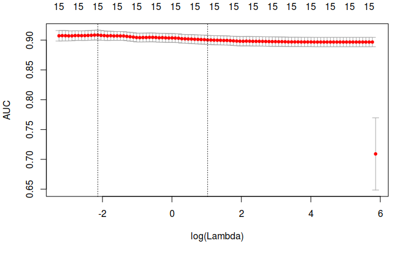

```r
# Let's see the results of Ridge regression
plot(ridge)
```

```r
coef(ridge, s=ridge$lambda.min)
```

```
16 x 1 sparse Matrix of class "dgCMatrix"
                        1
(Intercept) -3.000394e+00
V1          -4.563948e-02
V2           2.123550e-03
V3           1.438480e-02
V4          -2.700300e-01
V5          -8.695705e-02
V6           2.894889e-02
V7           8.716938e-03
V8           6.204985e-02
V9           1.702562e+00
V10          6.413384e-01
V11          5.636435e-02
V12         -8.496035e-03
V13         -8.696711e-02
V14         -5.998945e-04
V15          3.688097e-05
```

Second, let’s continue with the **Lasso** regularization:

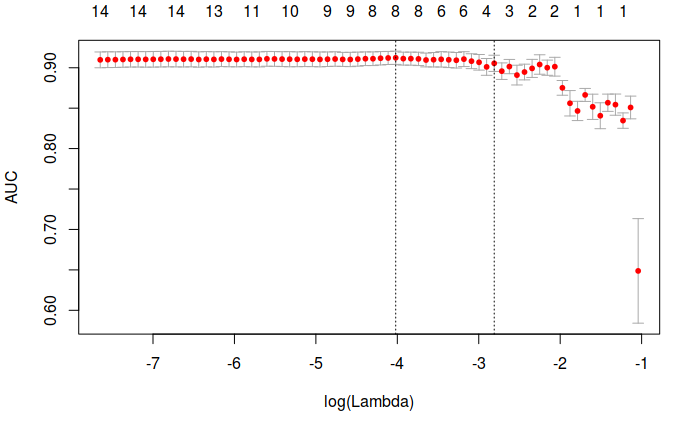

```r
# Let's apply the Lasso regression -> alpha = 1
set.seed(999)
lasso <- cv.glmnet(x.train, y.train, family='binomial', alpha=1, parallel=TRUE, standardize=TRUE, type.measure='auc')
# Let's see the results of Ridge regression
plot(lasso)
```

```r
coef(lasso, s=lasso$lambda.min)
```

```
16 x 1 sparse Matrix of class "dgCMatrix"
                        1
(Intercept) -5.151468e+00
V1           .
V2           .
V3           .
V4          -3.820963e-01
V5           .
V6           1.836281e-02
V7           .
V8           3.634193e-02
V9           3.027315e+00
V10          7.137857e-01
V11          6.227919e-02
V12          .
V13          .
V14         -4.452103e-04
V15          4.670959e-05
```

Third, let’s compare the models:

- **Ridge** has obtained the following `AUC`:

```r
max(ridge$cvm)
```

```
[1] 0.9084336
```

- **Lasso** has obtained the following `AUC`:

```r
max(lasso$cvm)
```

```
[1] 0.9123008
```

For these result, the selected model is **Lasso**, because it give higher `AUC` value. Its metrics are:

```r
library(caret)
lasso.pred <- as.numeric(predict.glmnet(lasso$glmnet.fit, newx = x.test, s = lasso$lambda.min) > 0.5)
lasso.confusionMatrix <- confusionMatrix(y.test, lasso.pred, mode = "everything")
lasso.confusionMatrix
```

```
Confusion Matrix and Statistics

          Reference
Prediction  0  1
         0 85  1
         1  7  7

               Accuracy : 0.92
                 95% CI : (0.8484, 0.9648)
    No Information Rate : 0.92
    P-Value [Acc > NIR] : 0.5926

                  Kappa : 0.5951
 Mcnemar's Test P-Value : 0.0771

            Sensitivity : 0.9239
            Specificity : 0.8750
         Pos Pred Value : 0.9884
         Neg Pred Value : 0.5000
              Precision : 0.9884
                 Recall : 0.9239
                     F1 : 0.9551
             Prevalence : 0.9200
         Detection Rate : 0.8500
   Detection Prevalence : 0.8600
      Balanced Accuracy : 0.8995

       'Positive' Class : 0
```

### 5. Give the *log odds* of the predictors variables above the objective variable.

```r
# The coefficients of the model are:
coef(lasso, s=lasso$lambda.min)
```

```
16 x 1 sparse Matrix of class "dgCMatrix"
                        1
(Intercept) -5.151468e+00
V1           .
V2           .
V3           .
V4          -3.820963e-01
V5           .
V6           1.836281e-02
V7           .
V8           3.634193e-02
V9           3.027315e+00
V10          7.137857e-01
V11          6.227919e-02
V12          .
V13          .
V14         -4.452103e-04
V15          4.670959e-05
```

```r
# The log odds of the predictors are:
exp(coef(lasso, s=lasso$lambda.min))
```

```
16 x 1 Matrix of class "dgeMatrix"
                       1
(Intercept)  0.005790898
V1           1.000000000
V2           1.000000000
V3           1.000000000
V4           0.682429360
V5           1.000000000
V6           1.018532445
V7           1.000000000
V8           1.037010373
V9          20.641726840
V10          2.041705884
V11          1.064259432
V12          1.000000000
V13          1.000000000
V14          0.999554889
V15          1.000046711
```

### 6. If for each true positive we earn 100e and for each false positive we lost 20e, what rentability contributes apply this model?

Let’s see the confusion matrix obtained:

```r
lasso.confusionMatrix$table
```

```
          Reference
Prediction  0  1
         0 85  1
         1  7  7
```

The rentability of this model is:

```r
85*100 - 1*20
```

```
[1] 8480
```